# week3

진수정

2021 3 21

# [ Ch 1. 모델링을 위한 전처리 ]

## 문제 0. 기본세팅

```r
rm(list = ls())
library(tidyverse)
library(data.table)
library(gridExtra)
setwd("D:/학회/2021-1/패키지/3주차")
train = fread('data.csv',data.table = FALSE)
test = fread('test.csv',data.table = FALSE)
```

## Train data 전처리 및 EDA

## 문제 1.

```r
# bmi: numeric으로 바꾸기
train$bmi = as.numeric(train$bmi)

# bmi: NA 값을 mean imputation으로 채우기
train$bmi[is.na(train$bmi)] = mean(train$bmi,na.rm = T)

# 채워진 거 확인
train$bmi %>% is.na %>% sum
```

```
## [1] 0
```

## 문제 2.

```r
# 문자형 변수 -> 명목형 변수로 바꾸기
train = train %>% mutate_if(is.character,as.factor)

# 바뀐 거 확인
str(train)
```

```
## 'data.frame':    4087 obs. of  12 variables:
##  $ id               : int  9046 51676 31112 60182 1665 53882 10434 27419 60491 12109 ...
##  $ gender           : Factor w/ 3 levels "Female","Male",..: 2 1 2 1 1 2 1 1 1 1 ...
##  $ age              : num  67 61 80 49 79 74 69 59 78 81 ...
##  $ hypertension     : int  0 0 0 0 1 1 0 0 0 1 ...
##  $ heart_disease    : int  1 0 1 0 0 1 0 0 0 0 ...
##  $ ever_married     : Factor w/ 2 levels "No","Yes": 2 2 2 2 2 2 1 2 2 2 ...
##  $ work_type        : Factor w/ 5 levels "children","Govt_job",..: 4 5 4 4 5 4 4 4 4 4 ...
##  $ Residence_type   : Factor w/ 2 levels "Rural","Urban": 2 1 1 2 1 1 2 1 2 1 ...
##  $ avg_glucose_level: num  229 202 106 171 174 ...
##  $ bmi              : num  36.6 28.8 32.5 34.4 24 ...
##  $ smoking_status   : Factor w/ 4 levels "formerly smoked",..: 1 2 2 3 2 2 2 4 4 2 ...
##  $ stroke           : int  1 1 1 1 1 1 1 1 1 1 ...
```

## 문제 3.

```r
# id 변수 제거
train = train %>% select(-id)
```

## 문제 4.

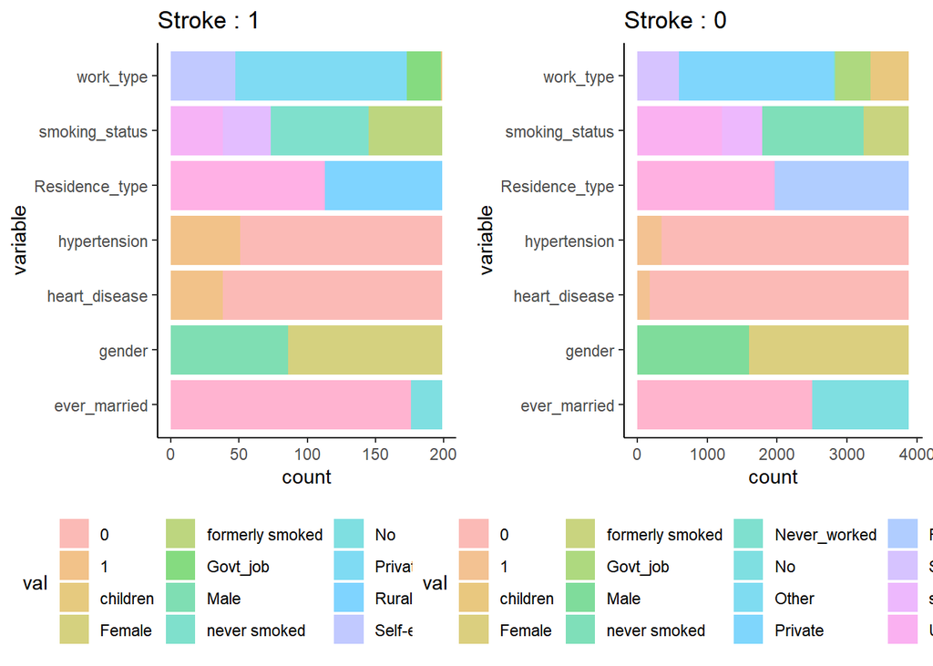

```r
# 타겟값별로 범주형 변수의 분포 시각화
p1 = train %>%
  filter(stroke == 1) %>%
  select(gender,hypertension,heart_disease,ever_married,
         work_type,Residence_type,smoking_status) %>%
  gather(key = 'var',value = 'val')  %>%
  ggplot(aes(x = var,fill = val)) +
  geom_bar(alpha = 0.5) +
  coord_flip() +
  theme_classic() +
  xlab('variable') +
  ggtitle('Stroke : 1') +
  theme(legend.position = 'bottom')

p2 = train %>%
  filter(stroke == 0) %>%
  select(gender,hypertension,heart_disease,ever_married,
         work_type,Residence_type,smoking_status) %>%
  gather(key = 'var',value = 'val')  %>%
  ggplot(aes(x = var,fill = val)) +
  geom_bar(alpha = 0.5) +
  coord_flip() +
  theme_classic() +
  xlab('variable') +
  ggtitle('Stroke : 0') +
  theme(legend.position = 'bottom')

grid.arrange(p1,p2,ncol = 2)
```

뇌졸중이 없는 집단과 비교했을 때 뇌졸중을 가진 집단에서  
1) (work type)어린이의 비율이 낮았고  
2) (smoking status) formerly smoked 비율이 높았고  
3) (hypertension) 고혈압 환자의 비중이 높았고  
4) (heart_disease) 심장병 환자의 비중이 높았고  
5) (ever_married) ever married 비중이 높았다.

## 문제 5.

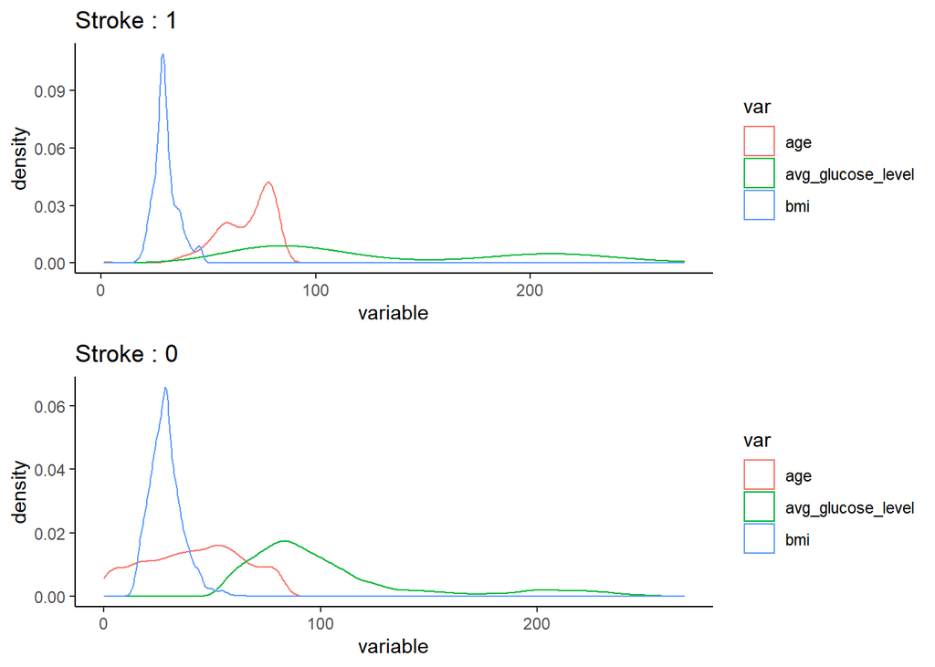

```r
# 타겟값별로 수치형 변수의 분포 시각화
p1 = train %>%
  filter(stroke == 1) %>%
  select(age,avg_glucose_level,bmi) %>%
  gather(key = 'var',value = 'val') %>%
  ggplot() +
  geom_density(aes(x = val,color = var)) +
  theme_classic() +
  xlab('variable') +
  ylab('density') +
  ggtitle('Stroke : 1')

p2 = train %>%
  filter(stroke == 0) %>%
  select(age,avg_glucose_level,bmi) %>%
  gather(key = 'var',value = 'val') %>%
  ggplot() +
  geom_density(aes(x = val,color = var)) +
  theme_classic() +
  xlab('variable') +
  ylab('density') +
  ggtitle('Stroke : 0')

grid.arrange(p1,p2,nrow = 2)
```

뇌졸중이 없는 집단과 비교했을 때 뇌졸중을 가진 집단에서  
1) avg_glucose_level의 분산이 더 컸으며,  
2) age는 상대적으로 특정 연령대에 집중적으로 분포되어 있다.

## 문제 6.

```r
# 범주형 변수 리스트
cate_var = c('gender','hypertension','heart_disease',
               'ever_married','work_type','Residence_type',
               'smoking_status')
# df 초기화
chi_result = data.frame(cate_var = cate_var,
                        chi = rep(NA,7))

# 독립성 검정 시행 후 결과 채워 넣기
for (i in 1:7) {
  chi_test = chisq.test(train[,cate_var[i]],train$stroke)

  res = ifelse(chi_test$p.value < 0.05,'denied','accept')
  chi_result$chi[i] = res
}

rm(chi,chi_test,cate_var,i,res)

chi_result
```

```
##         cate_var    chi
## 1         gender accept
## 2   hypertension denied
## 3  heart_disease denied
## 4   ever_married denied
## 5      work_type denied
## 6 Residence_type accept
## 7 smoking_status denied
```

## 문제 7.

```r
# 독립성 검정에서 기각하지 못한 범주형 변수 제거
dim(train)
```

```
## [1] 4087   11
```

```r
# gender, residence_type 제거
train = train %>% select(-c(gender,Residence_type))

# 제거되었는지 확인
dim(train)
```

```
## [1] 4087    9
```

## 문제 8.

```r
## bmi 변수 의 자료형 을 바꾸고 mean imputation 하기

# bmi: numeric으로 바꾸기
test$bmi = as.numeric(test$bmi)

# bmi: NA 값을 mean imputation으로 채우기
test$bmi[is.na(test$bmi)] = mean(test$bmi,na.rm = T)

# 채워짐
test$bmi %>% is.na %>% sum
```

```
## [1] 0
```

```r
## 문자형 변수 자료형 바꾸기

# 문자형 변수 -> 명목형 변수로 바꾸기
test = test %>% mutate_if(is.character,as.factor)

# 바뀌었는지 확인
str(test)
```

```
## 'data.frame':    1023 obs. of  12 variables:
##  $ id               : int  56669 58202 13861 38047 69160 47306 47167 38829 58631 72366 ...
##  $ gender           : Factor w/ 2 levels "Female","Male": 2 1 1 1 2 2 1 1 2 2 ...
##  $ age              : num  81 50 52 65 59 58 77 82 73 76 ...
##  $ hypertension     : int  0 1 1 0 0 0 1 0 1 0 ...
##  $ heart_disease    : int  0 0 0 0 0 0 0 0 0 0 ...
##  $ ever_married     : Factor w/ 2 levels "No","Yes": 2 2 2 2 2 1 2 2 2 2 ...
##  $ work_type        : Factor w/ 5 levels "children","Govt_job",..: 4 5 5 4 4 4 5 4 5 4 ...
##  $ Residence_type   : Factor w/ 2 levels "Rural","Urban": 2 1 2 1 1 1 2 1 2 2 ...
##  $ avg_glucose_level: num  186 167 233 101 212 ...
##  $ bmi              : num  29 30.9 48.9 28.2 29.2 ...
##  $ smoking_status   : Factor w/ 4 levels "formerly smoked",..: 1 2 2 1 1 4 2 2 2 4 ...
##  $ stroke           : int  1 1 1 1 1 1 1 1 1 1 ...
```

```r
## ‘id’ 및 train 데이터에서 제거된 범주형 변수 제거하기
test = test %>% select(-c(id,gender,Residence_type))
```

# [ Ch 2. Catboost ]

```r
library(catboost)
library(caret)
library(MLmetrics)
```

## 문제 0.

catboost 모델의 특성:  
- 범주형 변수가 많은 데이터를 처리하는데 유용한 알고리즘으로, 범주형 변수에 대해 자체적인 인코딩을 진행하여 속도가 빠르다.  
- ordered boosting 기법을 사용하여 과적합을 방지하며 효율적인 테스트를 수행할 수 있다.

catboost의 대표적인 파라미터:  
- iteration: 생성할 수 있는 최대 트리 개수  
- depth: 트리의 깊이  
- learning rate: 각 예측기마다의 학습의 가중치  
- l2 length reg: 비용 함수의 L2 regularization term의 계수  
- random strength: 각 split에 점수를 매길 때 사용할 randomness의 양

## 문제 1.

```r
# expand.grid로 다음의 df 만들기
logloss_cb = expand.grid(
  depth = c(4,6,8),
  iterations = c(100,200),
  logloss = NA
)
logloss_cb
```

```
##   depth iterations logloss
## 1     4        100      NA
## 2     6        100      NA
## 3     8        100      NA
## 4     4        200      NA
## 5     6        200      NA
## 6     8        200      NA
```

## 문제 2.

```r
# cv fold 생성
set.seed(1234)
cv = createFolds(train$stroke,k = 5)

start_time = Sys.time()

for (i in 1:nrow(logloss_cb)) {
  temp_logloss = NULL

  # 5-fold cv
  for (j in 1:5) {

    # 데이터 형식 변환
    valid_idx = cv[[j]]
    cv_valid = catboost.load_pool(
      data = train[valid_idx,names(train) != 'stroke'],
      label = train[valid_idx,'stroke'],
      cat_features = c(4,5,8))

    cv_train = catboost.load_pool(
      data = train[-valid_idx,names(train) != 'stroke'],
      label = train[-valid_idx,'stroke'],
      cat_features = c(4,5,8))

    # 파라미터 리스트
    param_list = list(
      loss_function = 'Logloss',
      logging_level = 'Silent',
      random_seed = 1234,
      depth = logloss_cb$depth[i],
      iterations = logloss_cb$iterations[i]
    )

    cb_model = catboost.train(cv_train,
                              params = param_list)

    cb_pred = catboost.predict(cb_model,cv_valid,
                               prediction_type = 'Class')

    temp_logloss[j] = LogLoss(cb_pred,train[valid_idx,'stroke'])
  }

  logloss_cb[i,'logloss'] = mean(temp_logloss)
}

print(paste("총 걸린 시간: ", Sys.time() - start_time, sep = ""))
```

```
## [1] "총 걸린 시간: 37.7477269172668"
```

## 문제 3.

```r
# 가장 낮은 logloss 값의 행 출력
logloss_cb = logloss_cb %>%
  arrange(logloss)

opt_param = logloss_cb[1,]
opt_param
```

```
##   depth iterations  logloss
## 1     6        100 1.715493
```

## 문제 4.

```r
# 데이터 형식 변환
test_pool = catboost.load_pool(
  data = test[,names(test) != 'stroke'],
  label = test[,'stroke'],
  cat_features = c(4,5,8))

train_pool = catboost.load_pool(
  data = train[,names(train) != 'stroke'],
  label = train[,'stroke'],
  cat_features = c(4,5,8))

# 파라미터 리스트
param_list = list(
  loss_function = 'Logloss',
  logging_level = 'Silent',
  random_seed = 1234,
  depth = opt_param$depth,
  iterations = opt_param$iterations
  )

# 최적 파라미터로 전체 데이터 학습시켜 test 셋에 대한 logloss 값 구하기
opt_cb = catboost.train(train_pool,
                        params = param_list)

cb_pred = catboost.predict(opt_cb,test_pool,
                               prediction_type = 'Class')

LogLoss(cb_pred,test[,'stroke'])
```

```
## [1] 1.721875
```

# [ Ch 3. K-means Clustering ]

```r
library(factoextra)
library(cluster)
```

## 문제 1.

```r
# 수치형 변수 정규화 스케일링 하기
train2 = train %>%
  mutate(age = scale(age),
         avg_glucose_level = scale(avg_glucose_level),
         bmi = scale(bmi)) %>%
  select(age,avg_glucose_level,bmi)
```

## 문제 2.

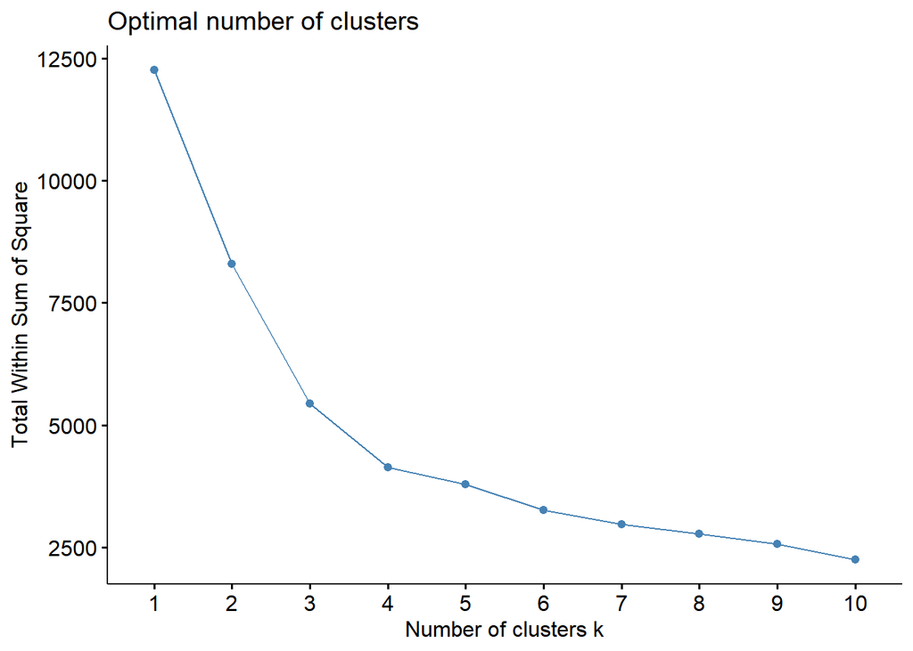

```r
# 시각화한 후 k값 정하기
fviz_nbclust(train2,kmeans,method = 'wss')
```

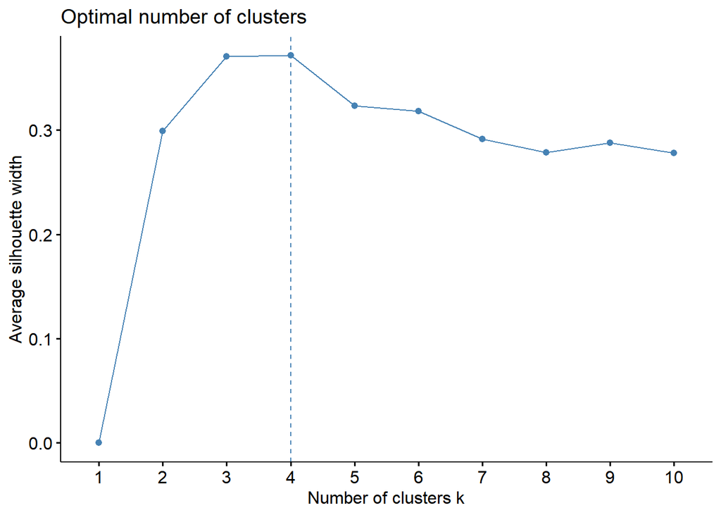

```r
fviz_nbclust(train2,kmeans)
```

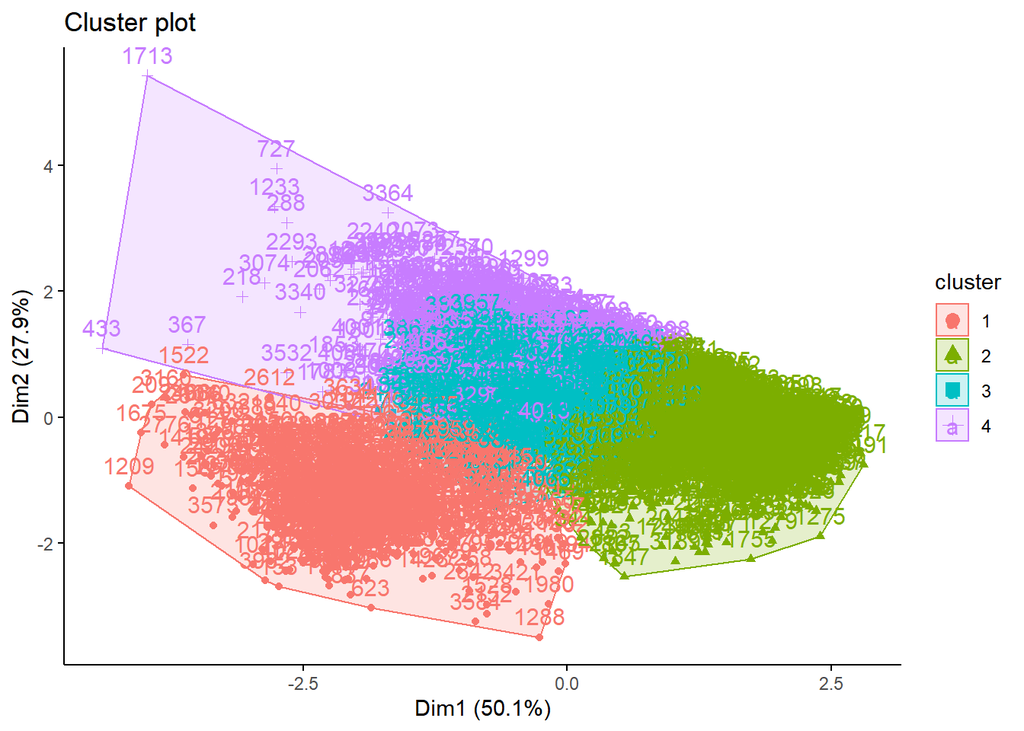

```r
# k-means 클러스터링 한 후, 시각화
set.seed(1234)
k4 = kmeans(train2,centers = 4,nstart = 1,iter.max = 30)

fviz_cluster(k4,train2,ggtheme = theme_classic())
```

k = 4에서 average silhouette 값이 최대가 되지만, 위의 플랏을 보면 cluster 3과 cluster 4의 구분이 제대로 되고 있지 않다.  
한편 k = 3일 때 average silhouette값은 k = 4일 때와 큰 차이가 나지 않으므로 k = 3으로 선택하였다.

## 문제 3.

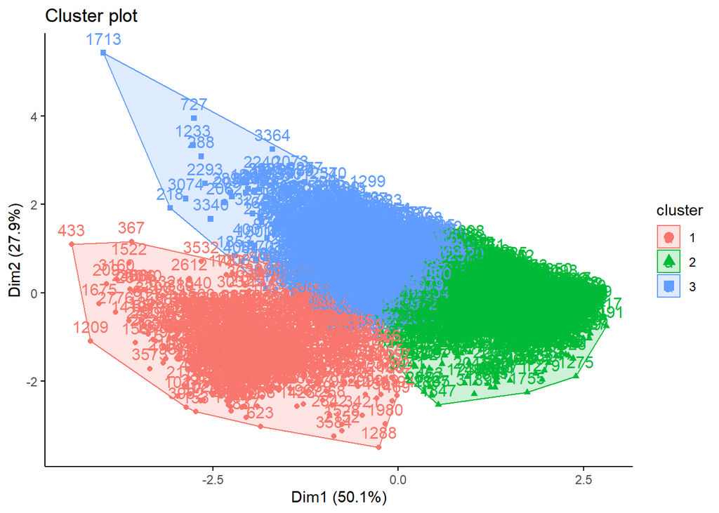

```r
# k-means 클러스터링 한 후, 시각화
set.seed(1234)
k3 = kmeans(train2,centers = 3,nstart = 1,iter.max = 30)

fviz_cluster(k3,train2,ggtheme = theme_classic())
```

## 문제 4.

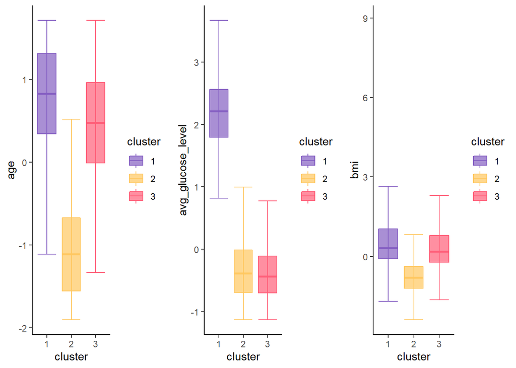

```r
# box plot 시각화를 한 후, 클러스터별로 해석하기
train2$cluster = k3$cluster %>% as.factor()

p1 = train2 %>%
  ggplot(aes(x = cluster,y = age,fill = cluster,color = cluster)) +
  geom_boxplot(outlier.shape = NA,alpha = 0.7) +
  stat_boxplot(geom = 'errorbar') +
  theme_classic() +
  scale_fill_manual(values = c('#845ec2', '#ffc75f', '#ff5e78')) +
  scale_color_manual(values = c('#845ec2', '#ffc75f', '#ff5e78'))


p2 = train2 %>%
  ggplot(aes(x = cluster,y = avg_glucose_level,fill = cluster,color = cluster)) +
  geom_boxplot(outlier.shape = NA,alpha = 0.7) +
  stat_boxplot(geom = 'errorbar') +
  theme_classic() +
   scale_fill_manual(values = c('#845ec2', '#ffc75f','#ff5e78')) +
  scale_color_manual(values = c('#845ec2', '#ffc75f', '#ff5e78'))

p3 = train2 %>%
  ggplot(aes(x = cluster,y = bmi,fill = cluster,color = cluster)) +
  geom_boxplot(outlier.shape = NA,alpha = 0.7) +
  stat_boxplot(geom = 'errorbar') +
  theme_classic() +
   scale_fill_manual(values = c('#845ec2', '#ffc75f','#ff5e78')) +
  scale_color_manual(values = c('#845ec2', '#ffc75f', '#ff5e78'))

grid.arrange(p1,p2,p3,ncol = 3)
```

- age: 1,3번 클러스터와 비교했을 때 2번 클러스터는 age값이 작게 분포되어 있다.
- avg_glucose_level: 2,3번 클러스터와 비교했을 때 1번 클러스터는 avg_glucose_level이 높게 분포되어 있다.
- bmi: 1,3번 클러스터와 비교했을 때 2번 클러스터의 bmi값은 작게 분포되어 있다.